# Maximum Likelihood

Emily Simmonds

## Instructions

This module accompanies the video lectures from week 2, which are on Panopto and embedded here.

This document contains information, questions, R code, and plots.

**Hints and reminders are in bold**

Questions appear in blue.

```r
# R code looks like this.
# Comments are in grey and explain the code

2+2 # add two and two
```

```
## [1] 4
```

```r
# outputs from R appear like the above ^^^^
```

**This first exercise module does not need to be submitted. Answers will be posted on the website at the end of the week.**

Parts A-E cover statistical modelling Part F covers R

# R skills

- Sourcing a script
- Running functions
- Simulating data
- Plotting
- Using `rbinom()` to simulate data
- Using `dbinom()` to calculate likelihoods

# Definitions

- A **population** is the total number of things that fit in a particular category e.g. if you want to study the average pace of skiers in Norway, the population is all skiers in Norway ever. You can rarely measure a whole population, particularly in biology.
- **Sample** a subset of the population that we measure.
- **Parameter** a property or numerical characteristic of a population.
- **Likelihood** the probability of obtaining the observed data, given the parameter value.
- **Estimand** the parameter we want to estimate, the true population level parameter.
- **Estimator** the parameter we estimate from our data. We estimate the estimand with this.

# Part A - Land and Sea

Begin by watching the **Introduction video** Either [click here](https://ntnu.cloud.panopto.eu/Panopto/Pages/Viewer.aspx?id=7c9e1f6a-e7d4-4dd7-a39e-ae2000cda621) or watch below.

(NOTE: in the markdown document the video embed has been commented out. It should be manually copied and pasted into the html)

In the video Bob collected data using a globe. He span the globe and recorded if the he touched `Land` or `Sea` when it stopped spinning. Each time he picked a point on the globe, this gave a new data point. If he did this 12 times, he would have 12 data points. All of the data points are called a **sample** and the number of them is the **sample size**. So in this example you have a sample with a sample size of 12. If you repeat all of the 12 spins (data collection), you would have two samples, each with sample size 12.

[figure not shown]

Figure 1: Picture of globe: source = wikipedia

In reality it would take a long time to repeat the data collection many times to get many samples, so we have created an app to do this for this.

[Click for app](https://shiny.math.ntnu.no/qmbio/Shiny_apps/LandSea/)

[interactive chart not shown]

Open the app and have a go at collecting some data:

Try changing the number of points in your sample (sample size).

Also change the number of times you repeat the data collection (number of samples).

This app was created in R, it simulates the idea of collecting data in the way described above. Simulations can be very useful when it is hard to collect data ourselves.

In the app the code is hidden, but you can also source the code into your own R session and run the function there. It is not quite as pretty but you have more control. You now only get the data not the plots.

Run the lines below to source the function and try using it. You will need to enter arguments `NTrials` (your sample size) and `nSims` (number of times you repeat the sampling) and set `probability` to 0.4.

We will explain why the arguments have these names in Part B.

```r
# You can find the script with the functions for this week at this url:
# https://www.math.ntnu.no/emner/ST2304/2024v/Module02/Module02Functions.R

# Source the script directly from the internet
source('https://www.math.ntnu.no/emner/ST2304/2024v/Module02/Module02Functions.R')

# The functions should now be loaded,
# check your environment to be sure - you should have two functions there

# Use the function simGlobe
# try a few different combinations
result <- simGlobe(NTrials = 5, nSims = 1, probability = 0.4)

# Look at your results:
result
```

When you repeat the data collection more than once, do you get the same data?

If not, why not?

Does the probability of picking a point with a value `Land` change when you change the sample size or number of samples?

**ANSWERS**

When you repeat data collection, you should see different results. Each time you take a sample, it is different.

This is because it is a random process and we are only taking a subset of the whole population. Each subset is slightly different to the others.

No, the probability of each point being Land does not change even if the actual number we get is different.

# Part B - Inference

In Part A, you experimented with simulating data in R or in an app. Hopefully you could see that each time you took a **sample** of data from the **population** (every point in world), you got a different result. The difference in results should be greatest when the sample size is lowest.

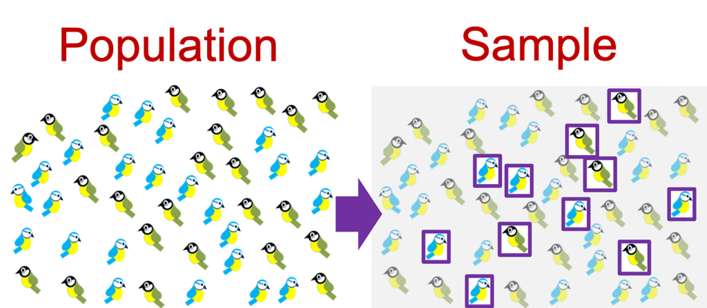

*Figure 2: Population and sample*

This happens because you are only collecting data on a subset of the population, which is chosen at random. Because different individuals (our individuals are points on the globe) are chosen each time you take a sample, you get different results when you measure them, **even though the population level proportion of land does not change.** In other words, the probability of sampling a point that is land is always the same. The same ‘true’ probability can produce many possible observed outcomes, there is **variation**.

Simulate one sample with a sample size of 10, either in R or on the app.

From this data, what do you guess is the proportion of land on earth?

How confident are you that this guess is correct for the whole of globe (**The population**)?

Hopefully you are not very confident that the proportion you calculated from the single sample is correct for the whole population. As you saw in Part A, there can be a lot of variation in observed data and our sample is just one realisation, see Figure 3 for an example.

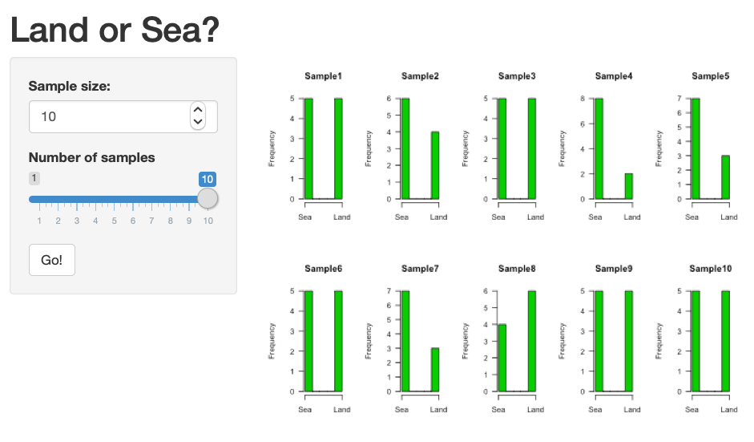

*Figure 3: Different samples of land and sea*

But really we are most interested in the population, not the sample.  
Therefore, in statistics, we want to use information from a sample to tell us something about the population as a whole. We want to take into account the variability in possible outcomes and estimate properties (called **parameters**) of the population. This is called **statistical inference**.

Now watch **video 2**

Either [click here](https://ntnu.cloud.panopto.eu/Panopto/Pages/Viewer.aspx?id=3b325c3e-561c-47d5-a18f-ae2000bc8099) or watch below. (NOTE: in the markdown document the video embed has been commented out. It should be manually copied and pasted into the html)

## Statistical inference for the proportion of land and sea

The biological question we are asking in this example is: “What is the proportion of land cover on earth?”

To go from the data you collected on your sample, to saying something about the population takes several steps.

### Step 1 = to choose a model.

(This is a statistical modelling course after all.) When we say model, we are really talking about a mathematical representation of how we think the data were generated. Which model to choose, and how you decide this, is something we will come back to several times in this course. You need to match the characteristics of a distribution or equation to the characteristics of our data at the population level.

For the current example, you first need to think about your population level data.The type of data you collected are stored in the computer as `0` and `1`. `0` = `Sea` and `1` = `Land`. This is binary data, with land as a success and sea as a failure. Each time that someone puts their finger on the map and chooses a location, this is a **trial** with two possible outcomes, ‘success’ or ‘failure’ (this is why we have an Ntrials argument in the `simGlobe()` function).

You can imagine each time you choose a location you ask the question: “Is there land?” which would give a “yes” or “no” answer. Each time you conduct a trial, there is a certain **probability of success**. This probability is the same for each trial and each trial is independent.

Now you know these characteristics of your data, you can consider which distribution might be a good model for this data. In this case, the **binomial distribition** works well because it is a distribution of the number of successes from independent trials with a binary outcome.

### Step 2 = estimate parameters.

Every distribution or other model we use in this course, has some properties, which control its form. These are the **parameters** mentioned above and they can tell us things about the population.

To answer our biological question, you want to estimate the population level parameter $p$, which is the probability of choosing a point that is land. You can do this using the sample you generated above, in which case we know $n$ but we want to estimate $p$.

**We can say $n$ follows a binomial distribution with unknown probability of success $p$.**

$p$ is the **estimand**. It is what we want to estimate and we estimate it with an **estimator** $\hat{p}$. In other words, $p$ is the true population level parameter, $\hat{p}$ is what we estimate with statistics.

More on how to estimate the parameters in Part D.

### Step 3 = estimate the uncertainty.

As we saw from the first simulations, there can be a lot of variation in real data. The same ‘true’ parameter can produce many different data sets. It is also true that the same data set could be produced from several different ‘true’ parameters (this is different to the sentence before but might take some thinking about). For example with a ‘true’ proportion of land of 0.5 or 0.6 you could still get a result of 6 lands and 6 seas from a sample of size 12.

**This idea of variation is really important** we can try and visualise it too. You already saw how the same ‘true’ parameter can produce many data sets. Now we want to look at how different parameters can produce similar datasets.

Using the code below, simulate 100 observed data sets for $p$ = 0.4 AND $p$ = 0.6. Two histograms will be plotted. How many time was the same observed data created by both probabilities? For example, if you see Land 5 times, how often do you get it with $p=0.4$, and with $p=0.6$. What does this suggest about tyrying to estimate $p$?

```r
# Create a split screen to plot in
par(mfrow=c(1,2)) # one row and two columns

# Create the histograms
# we put the simGlobe function inside hist()
# simGlobe creates our x arugment for hist()
#["Land",] tells R to take only the row with number of Land
hist(simGlobe(0.4, 12, 100)["Land",], xlab = "Number of land",
     main = "0.4")
hist(simGlobe(0.6, 12, 100)["Land",], xlab = "Number of land",
     main = "0.6")
# main changes the title
# xlab changes the x label
```

When we estimate parameters, we also want to recognise the variation. We call it **uncertainty**, more on this next week.

### Step 4 = interpret results.

Once you have an estimate for the population and quantified uncertainty, you can go back to your biological question and interpret the results.

How confident are you now in your guess from the beginning of this section?

# Part C - Likelihoods

Once we have a model for our data, how do we decide what good estimates of the parameters of the model are? This can be difficult, as many different values could be possible. But we need an objective and repeatable way to estimate the ‘best’ parameter based on our data. In this course we do this using **likelihoods**.

The **likelihood** is defined as the probability of obtaining the observed data, given the parameter value. It represents how the data were generated. We assume that the data are random and the parameters are fixed. In our example this would be the probability of getting our number of lands given a particular probability of success.

## Getting a likelihood for our example (land and sea)

Watch the **final video**.

Either [click here](https://ntnu.cloud.panopto.eu/Panopto/Pages/Viewer.aspx?id=9c221c95-4e41-41b2-8de2-ae2200a0159c) or watch below.

As we said above, the likelihood is the probability of getting our observed data, given a parameter value $p$.

In this section we will walk you through how to write a likelihood for our land and sea data.

### 1: For the first step we will do this for just 1 trial.

Imagine we ran one trial and the data we got was `Land`, which is a success. **Remember: we can use the symbol $n$ to indicate the number of successes (theoretically) and $r$ is the actual number we observed**. The probability of getting our data is equal to $p$, because we only have one trial. This can be written as:

$$\begin{aligned}
Pr(n=r) &= p \\
\end{aligned}$$

where $Pr(n=r)$ is the probability of getting our data, in this case, one success (so $r=1$).

We can break this down: $Pr()$ means the probability of something, here the probability that $n$ equals $r$. $n$ is a *random variable*: it is a random number that can take one of several values. $r$ is the value it takes here. So, $Pr(n=r)$ is the probability that $n$ is value $r$. $Pr(n=r)$ is a number (e.g. 0.4), but here we do not know what that number is, so we call it $p$. And we want to find an estimate for $p$ (which we will - eventually - call $\hat{p}$).

### 2: Next we will look at 2 trials.

This time our data are `Land`, which is a success, then `Sea`, which is a failure. **$r$ is still used to indicate the observed number of successes, which = 1**. Using probability theory we can work out the probability of getting 1 success from our two trials. This can be written as:

$$\begin{aligned}
Pr(n=1) &= p(1-p) + (1-p)p = 2p(1-p)\\
\end{aligned}$$

where $Pr(n=1)$ is the probability of getting our data, in this case, one success (i.e. it is $Pr(n=r)$, with $r=1$).

In words, the equation shows that we could get one success in two ways (`Land-Sea` or `Sea-Land`). Each time the probability of `Land` = $p$ and the probability of `Sea` = $(1-p)$.

You can get to this equation using the probability tree you used in ST0103. See text book ‘The Analysis of Biological Data’ probability section or google probability tree, if you cannot remember.

### 3: More than 2 trials.

In points 1 and 2 it was easy to calculate the probability of obtaining the data manually using a probability tree. But, when we get into more trials, this would take a long time, and there are better options. In this case, we can use the equation for the binomial distribution to get to a more general likelihood, i.e. to work for any number of trials. The reasons we use the binomial distribution are explained in Part B.

**Now we use $N$ to indicate the number of trials**

We can write the equation like this, using the equation for a binomial distribution:

$$\begin{aligned}
Pr(n = r | N, p) &= \frac{N !}{r! (N-r)!} p^r (1-p)^{N-r}
\end{aligned}$$

where $Pr(n = r | N, p)$ is the probability of getting our observed data GIVEN the number of trials $N$ and the probability of success $p$ (our parameter).

In words, the equation shows has two parts:

- The first part $\frac{N !}{r! (N-r)!}$ counts the number of combinations of $r$ successes and $N-r$ which is the number failures. This uses combinatorics theory also from ST0103.
- The second part $p^r (1-p)^{N-r}$ is the probability of success $p$ to the power of the number of successes $r$ multiplied by the probability of failure $(1-p)$ to the power of the number of failures $N-r$.

Together they make the equation for a binomial distribution. We know $r$ and $N$ from our data but we need to put in a value of $p$ to use the equation. **This is important in Part D.**

### 4: Plugging in numbers.

Have a go at using the equation in point 3 to calculate a likelihood for the following:

5 trials and data = (`Land`, `Land`, `Land`, `Sea`, `Sea`).

$p$ = 0.5

You can use R or a calculator. If you use R, the function `factorial()` will take the factorial of a number and `^` takes the power. E.g.

```r
# Code to demonstrate factorial and power

factorial(5) # 5!

5^3 # 5 to the power of 3
```

**Remember to use brackets ().**

**ANSWER**

```r
# Code to demonstrate factorial and power

(factorial(5)/(factorial(3)*factorial((5-3))))*((0.5^3)*0.5^2)
```

If you have time, try and repeat the calculation for some different values of $p$. How does the likelihood change?

Next we will look at how we find the highest probability of getting our data.

# Part D - Using the likelihood

When we estimate parameters for our models, we want to find the parameter value that **gives the highest likelihood for our data**. This is called maximum likelihood estimation.

To find the highest likelihood (**to maximise the likelihood**) you need to calculate it for several different parameter values. Ideally, we should do this for all possible values the parameter could take. There are several ways that we can do this:

### Manually.

You already had a go at this in Part C by plugging numbers into the likelihood equation and getting an answer. But to do this for 100s of candidate parameter values would take much too long.

### Using R and `dbinom()`

There is a function in R called `dbinom()`. This function calculates the density of a binomial distribution from some input parameters (`x` = the observed number of successes, `size` = the number of trials, `prob` = the probability of success). This density in this case the proportion of times you would expect to get the observed number of successes for the given number of trials and the probability. Hopefully this sounds a bit familiar, the density here is the same as the likelihood.

As before, the parameter we want to estimate is $p$ (argument `prob` in the function), which is the probability of getting `Land`. To find the ‘best’ estimate of $p$ based on our observed data, we need to calculate the likelihood for many different values of $p$ and compare which gives the highest likelihood.

Use the code below to calculate the likelihood by hand for 10 candidate values for $p$.

The data for this are: 10 trials and data = (`Land` = 4, `Sea` = 6).

```r
# Code to use dbinom()

# First create an object containing your candidate values of p
probabilities <- seq(from = 0.1, to = 0.9, length.out = 10)

# Use dbinom to calculate the likelihoods
likelihoods <- dbinom(x = 4, size = 10, prob = probabilities)
```

Now use the `dbinom()` function to calculate the likelihood for 100 candidate values for $p$.

**ANSWERS**

```r
# Code to use dbinom()

# First create an object containing your candidate values of p
probabilities <- seq(from = 0.1, to = 0.9, length.out = 10)

probabilities
```

```
##  [1] 0.1000000 0.1888889 0.2777778 0.3666667 0.4555556 0.5444444 0.6333333
##  [8] 0.7222222 0.8111111 0.9000000
```

```r
# Use dbinom to calculate the likelihoods
likelihoods <- dbinom(x = 4, size = 10, prob = probabilities)

likelihoods
```

```
##  [1] 0.011160261 0.076124955 0.177432992 0.244962211 0.235562474 0.164923165
##  [7] 0.082106448 0.026247484 0.004128375 0.000137781
```

Plot the results using the code below. Discuss the plots in your group. What do they show? Can you guess which parameter value gives the maximum likelihood? Is it easy to read?

```r
# Plotting the likelihoods

# To plot we use the plot() function
# Our x is our probabilities and our y is the likelihoods
# We want a line graph with x and y labels that we choose
plot(x = probabilities, y = likelihoods,
     type = 'l', xlab = "Candidate value for p",
     ylab = "likelihood")
```

Now do the same for log likelihood.

To do this, you need to add one more argument to your the `dbinom()` function. `log = TRUE` this will calculate the log likelihood instead.

**Remember to change the y axis label.**

**ANSWERS**

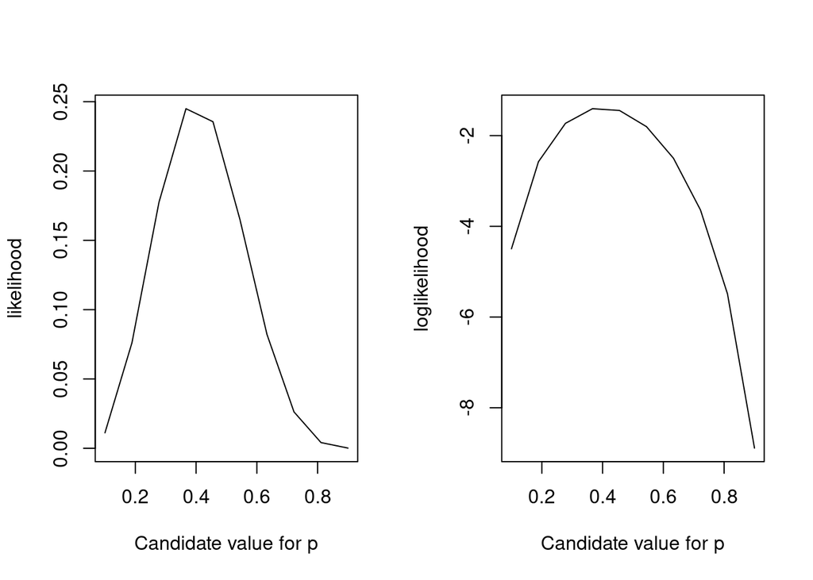

```r
par(mfrow=c(1,2)) # puts two plots side by side (1 row and 2 columns)

plot(x = probabilities, y = likelihoods,
     type = 'l', xlab = "Candidate value for p",
     ylab = "likelihood")

# make log likelihoods
loglikelihoods <- dbinom(x = 4, size = 10, prob = probabilities, log=TRUE)

plot(x = probabilities, y = loglikelihoods,
     type = 'l', xlab = "Candidate value for p",
     ylab = "loglikelihood")
```

Do you think this plot is any better?

We tend to use log likelihood because likelihood values get very small and it makes differences harder to see. Conveniently, the maximum is the same for raw likelihood and log likelihood.

Using whichever graph you prefer, can you find the maximum likelihood estimate for the parameter p?

This is not so easy from the graphs or the data alone. We cover more on how to find the maximum in Part E.

Try and write in your own words what the likelihood is and why we use it.

# Part E - Finding the maximum

In Part D you calculated likelihood values for several possible values of our parameter $p$. It was possible to find the maximum value from those you calculated, but this does not necessarily give us the actual **maximum** likelihood value. That is because we cannot guarantee that we tested **all** possible values of $p$.

There are several ways we can find the maximum:

### Analytical estimation (do maths)

**This is what we will use today.**

Analytical estimation works for the simple example we have here. It finds mathematically the point on the likelihood curve (what we plotted in Part D), where the gradient of the line is 0. To do this we find an equation for the slope and set the equation to 0. We can then solve this to find the value of $p$ when the slope is 0.

The equation for the slope is:

$$\frac{d l(p ; n)}{dp} = \frac{r}{p} - \frac{N-r}{1-p}$$

Where, $\frac{d l(p ; n)}{dp}$ is the change in likelihood over the change in $p$, $\frac{r}{p}$ is the number of successes over $p$, and $\frac{N-r}{1-p}$ is the number of failures over the probability of getting a failure.

If we set this to 0 we get:

$$0 = \frac{r}{p} - \frac{N-r}{1-p}$$

It can be rearranged to be :

$$\frac{p}{1-p} = \frac{r}{N-r}$$

This means that the odds of success $\frac{p}{1-p}$ (probability of success over probability of failure) are equal to the ratio of success to failure $\frac{r}{N-r}$.

This is also equal to:

$\hat{p} = \frac{r}{N}$

**remembering that $\hat{p}$ is our estimator, which is our ‘best’ estimate of $p$**

**$\hat{p}$ is the maximum likelihood estimate of $p$**

Using the final equation. Try and calculate the maximum likelihood estimate of $p$ for our example

**ANSWER**

Our example was 3 successes from 5 trials. So using the formula we do 3/5 = MLE = 0.6

### Now we have a maximum likelihood estimate, how does it change if we take more samples?

Consider what happens if we take another sample. Our data are now (`Land` = 2, `Sea` = 8). Will $\hat{p}$ be the same for this new sample?

We can look at this more easily in a graph. To do this we should estimate $\hat{p}$ for many different samples, all from the same population. We can then plot the results. We have made a function to help you do this called `mleGlobe()`. It calculates $\hat{p}$ for a given set of observed data. It takes two arguments: `NLand` = number of lands and `NTrials` = number of trials. **We assume the ‘true’ value of $p$ is 0.4**

This function was loaded at the same time as `simGlobe()` in Part A. **Go back to Part A if the function is no longer loaded.** The two functions `simGlobe()` and `mleGlobe()` can be combined as follows:

```r
# Example of a single use of mleGlobe()
# 6 land values from 12 trials
# This produces two probability values, one for Sea and one for Land
# we only care about the Land one
mleGlobe(NLand = 6, NTrials = 12)

# Using simGlobe as the input
# ["Land",] takes only the lands from the simGlobe output
result <- mleGlobe(NLand = simGlobe(probability = 0.4,
                                    NTrials = 12,
                                    nSims = 10)["Land",],
                   NTrials = 12)

result
```

Use the code above to calculate the maximum likelihood estimator for many different samples (change the nSims argument).

We can plot the results using the `hist()` function. This makes a histogram of the data.

```r
# Plot the results in a histogram
hist(result,
     main = "Histogram of results",
     xlab = "MLE of p")

# main changes the title
```

What do you think of the graph? and how does it change as the number of samples changes?

**We will think about this more when we cover uncertainty.**

### Numerical and simulation estimation

It is not always possible to find the maximum likelihood estimate analytically. Therefore, in many situations we use either numerical or simulation estimation.

In numerical estimation, we use an algorithm to find the maximum.

For simulation, we simulate the likelihood by simulating repeated sampling many times and calculating how often a particular set of data are generated. Then we find the set of parameters that produce the observed data most often.

# Part F - R - Inside the functions

This week we used several functions. The main ones were: `rbinom()`, `dbinom()`.

Both of these functions use the binomial distribution. `rbinom()` generates a random value from the binomial distribution and `dbinom()` produces a density (the proportion of times you get the observed number of successes from the probability $p$ you enter). You can find out more about them in the help pages by typing `?dbinom` into R.

This type of function exists for many different kinds of distributions. We will use them a lot in this course.

We also used these functions within the ones we wrote for this course. The full code with comments for this week’s functions `simGlobe()` and `mleGlobe()` can be found in the [script](https://www.math.ntnu.no/emner/ST2304/2020v/Week02/Week2Functions.R).

**Reminder for arguments** you can input arguments to a function either by naming them e.g. `plot(x=2, y=3)` or by typing them in order e.g. `plot(2, 3)`. If doing the second option, you MUST put them in the right order, so it is important to remember or check what the function expects.

# Finally

[Here is a video summarising this week’s module](https://ntnu.cloud.panopto.eu/Panopto/Pages/Viewer.aspx?id=9c221c95-4e41-41b2-8de2-ae2200a0159c), running through some of the main themes (and talking too much about the R code).